# Fundamentos de programación y análisis de datos en R

## Outputs

## Archivos csv

Los archivos separados por comas son uno de los formatos más utilizados para compartir información. En *R* podemos crear estos tipos de archivos con la función: *write.csv()*.

Siguiendo con el ejemplo que estamos trabajando, vamos a guardar la variable *estimacion* en nuestros equipos. Para ello empleamos los siguientes comandos:

```r
write.csv(estimacion, file = "DR/acciones/descriptivas.csv",
          row.names = FALSE
          )
```

*estimacion* debe existir en el ambiente de trabajo y *file* es la ruta donde deseamos guardar el archivo, note que incluye el nombre y la extención.

## Imágenes

Los *plots* se pueden guardar en diferentes formatos: *png*, *jpg*, *svg*, *bmp*, *tiff* entre otras. Esta acción se puede llevar acabo vía interfaz o mediante líneas de comando. Esta última tiene la ventaja de automatizar el procedimiento.

El siguiente código guarda una imágen en formato *svg*.

```r
# Se abre el dispositivo (svg).
svg(filename = "plot/probabilidad.svg")

# Se realiza el gráfico.
plot(estimacion[, 3], type = "l")

# Se cierra el dispositivo.
dev.off()
```

La función *graficos_precio()* la podemos modificar para que guarde todos los gráficos en el siguiente directorio: *plot/acciones/*.

```r
graficos_precio <- function(x) {
  nombre <- colnames(x)[2]
  nombre <- gsub(pattern = ".Open", replacement = "", nombre)
  ruta <- paste0("plot/acciones/", nombre, ".svg")
  svg(ruta)
  plot(x[, 1], x[, 4], type = "l", main = nombre,
       ylab = "Precio", xlab = "Año")
  grid(30, 30)
  dev.off()
  return(NULL)
}
```

## Introdución a *Tidyverse*

**Tidyverse** es un conjunto de paquetes para realizar ciencia de datos. Estos paquetes comparten un mismo marco o gramática que crean una sinergía en el análisis. Varios de estos fueron escritos por [Hadley Wickham](https://hadley.nz/) en [RStudio](https://www.rstudio.com/).

Estos paquetes permiten limpiar, describir, modelar y graficar datos de manera sencilla. Entre ellos se destacan:

- [**ggplot2**](https://ggplot2.tidyverse.org/): Este paquete permite realizar gráficos y esta básado en [*The Grammar of Graphics*](https://www.amazon.com/Grammar-Graphics-Statistics-Computing/dp/0387245448/ref=as_li_ss_tl) de [Leland Wilkinson](https://en.wikipedia.org/wiki/Leland_Wilkinson).
- [**dplyr**](https://dplyr.tidyverse.org/): Este paquete permite manipular datos a partir de una gramatica basada en 5 verbos.
- [**tidyr**](http://vita.had.co.nz/papers/tidy-data.html): Esta colección de funciones ayudan a organizar datos en una forma adecuada para realizar anális de datos.

[Paquetes recomendados](https://www.rstudio.com/products/rpackages/)

Estos paquetes pueden ser instalados mediente el siguiente comando:

```r
install.packages("tidyverse")
```

El comando anterior solo se requiere ejecutar una vez. Luego de instalados podemos cargar las funciones con la siguiente línea de código:

```r
library("tidyverse")
```

La línea anterior se debe ejecutar cada vez que se inicie una nueva sesión en R.

## *ggplot2*

Este paquete es utilizado para realizar gráficos estadísticos y esta basado en la grámatica desarrollada por Wilkinson (1999). Esta gramática responde a la pregunga ¿Que es un gráfico estadístico? (Wickham 2010).

Estos gráficos son el resultado de asignar atributos estéticos (colores, formas, tamaños) a un conjunto de datos. *ggplot2* permite incorporar un conjunto de componentes independientes en un mismo *‘‘layout’’* para crear visualizaciones robustas.

Extenciones se han realizado para crear [arte algoritmico](https://en.wikipedia.org/wiki/Algorithmic_art). Algunos ejemplos: [Antonio Sánchez](https://fronkonstin.com/), [Thomas Lin Pedersen](https://www.data-imaginist.com/), [aRtsy](https://koenderks.github.io/aRtsy/), [R Image Art](http://mfviz.com/r-image-art/), [Getting Started with Generative Art in R](https://towardsdatascience.com/getting-started-with-generative-art-in-r-3bc50067d34b).

### Elementos básicos

Para una mayor comprensión consultar Wickham (2010).

### Ejemplo

En este ejemplo vamos a trabajar con las medidas descriptivas que se obtuvieron de las acciones.

```r
library(ggplot2)
library(readr)
 datos_acciones <- read_csv(
   file = "../Datos/Fin_Semana_2/descriptivas.csv"
   )

head(datos_acciones[1:5], 3)
## # A tibble: 3 x 5
##   rendimientos riesgo probabilidad intercepto pendiente
##          <dbl>  <dbl>        <dbl>      <dbl>     <dbl>
## 1     0.000545 0.0180        0.517      -152.    0.0117
## 2     0.00119  0.0292        0.512      -257.    0.0176
## 3     0.000449 0.0184        0.517      -543.    0.0403
```

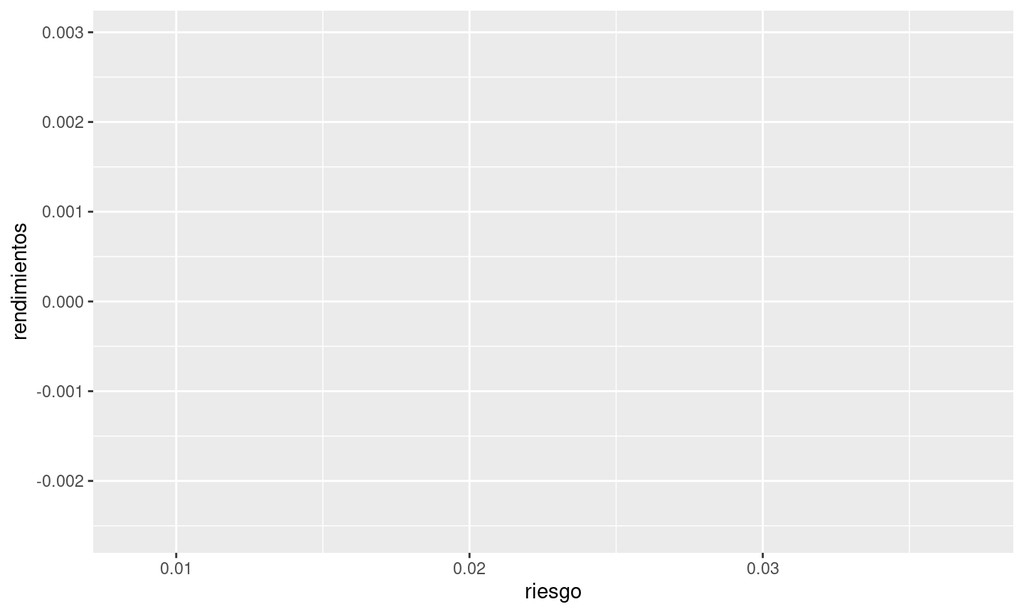

```r
ggplot(data = datos_acciones, aes(riesgo, rendimientos))
```

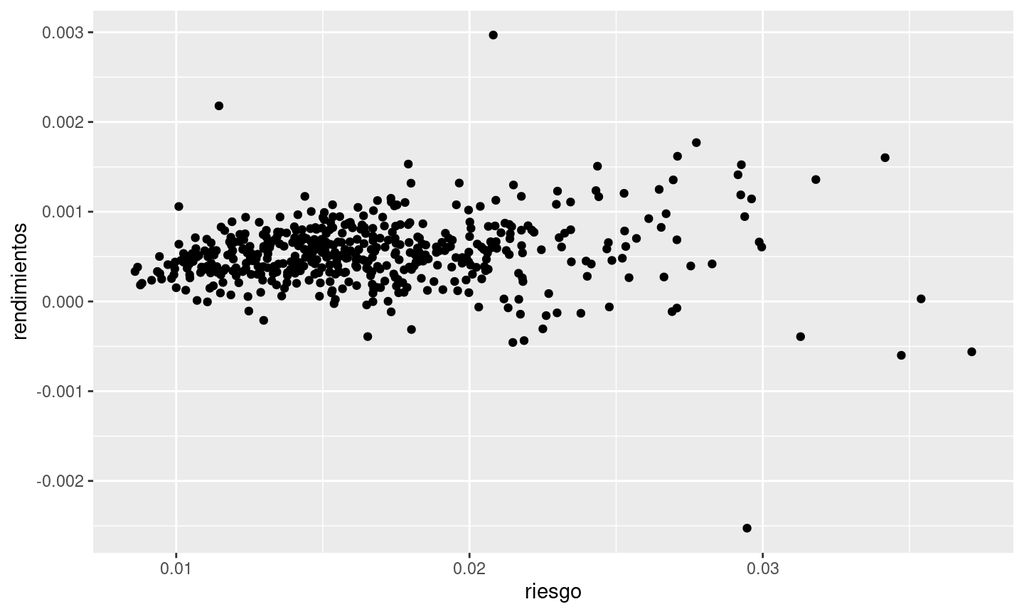

```r
ggplot(data = datos_acciones, aes(riesgo, rendimientos)) +
  geom_point()
```

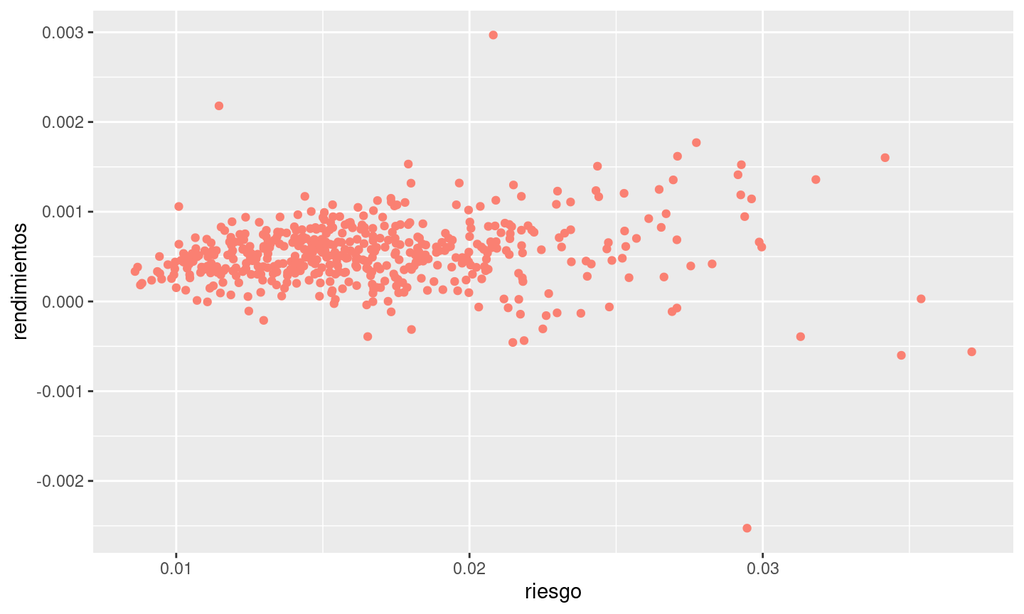

```r
ggplot(data = datos_acciones, aes(riesgo, rendimientos)) +
  geom_point(colour = "salmon")
```

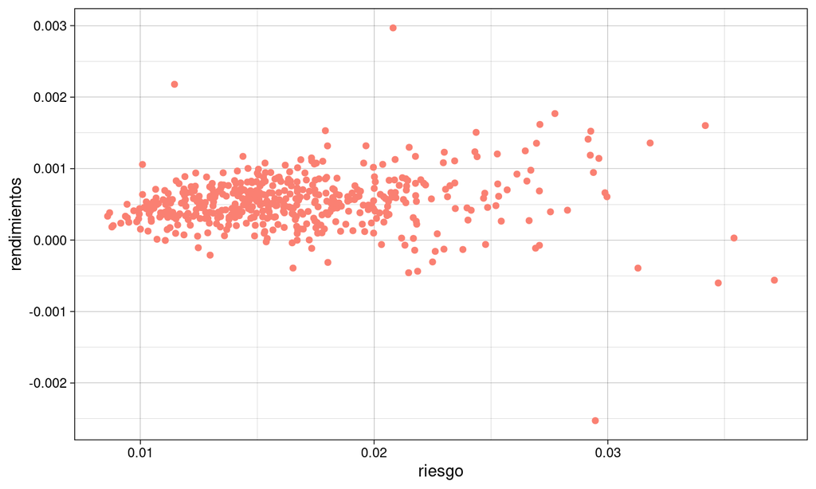

```r
ggplot(data = datos_acciones, aes(riesgo, rendimientos)) +
  geom_point(colour = "salmon") + theme_linedraw()
```

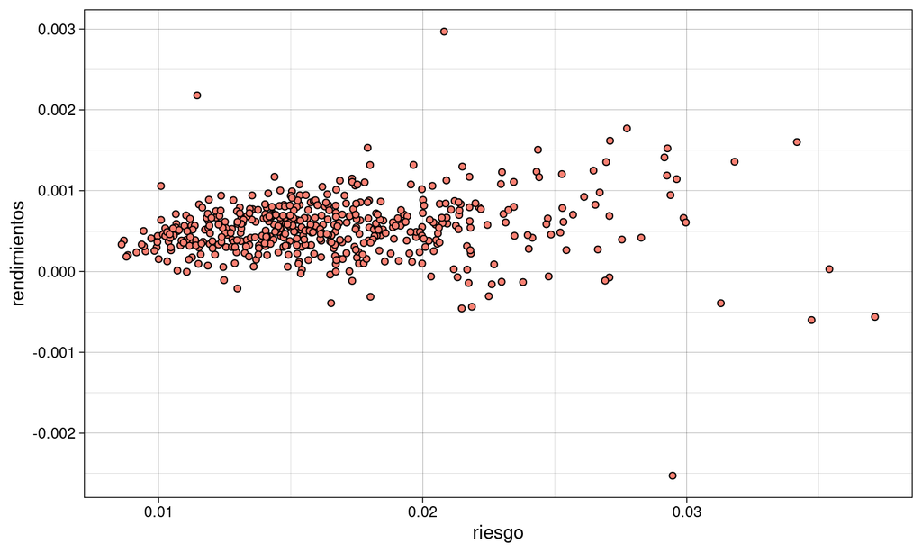

```r
ggplot(data = datos_acciones, aes(riesgo, rendimientos)) +
  geom_point(shape = 21, colour = "black", fill = "salmon") +
  theme_linedraw()
```

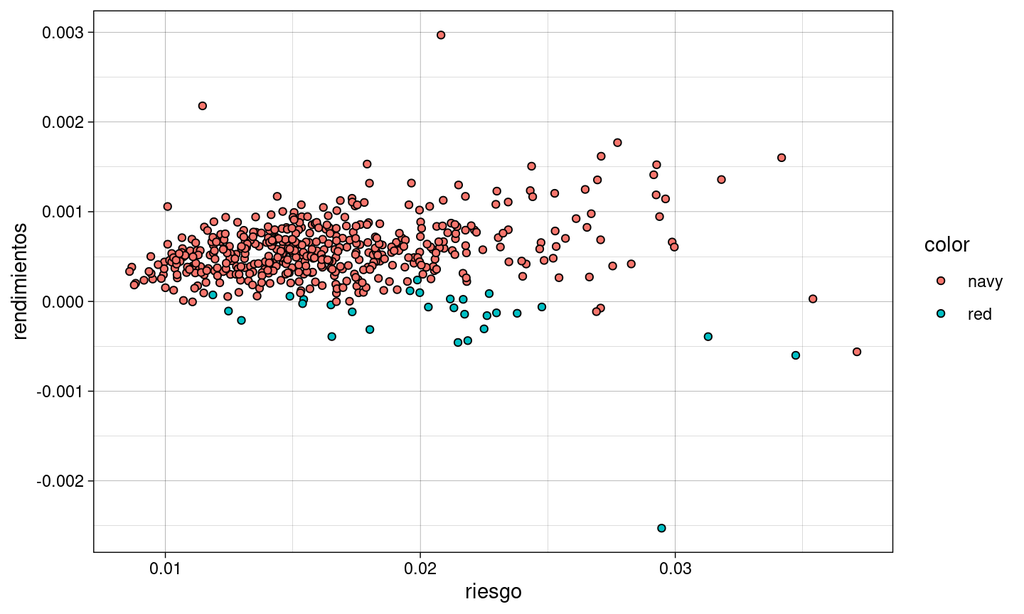

```r
ggplot(data = datos_acciones,
    aes(x = riesgo, y = rendimientos, fill = color)
       ) +  geom_point(shape = 21) + theme_linedraw()
```

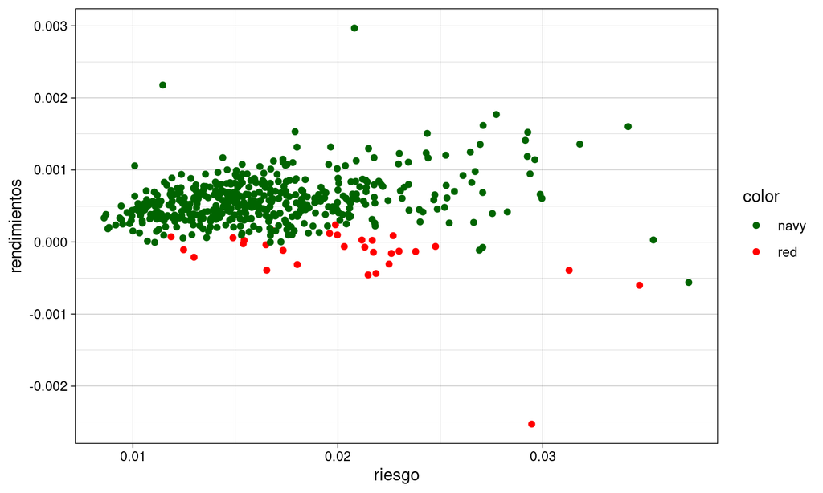

```r
ggplot(data = datos_acciones,
    aes(x = riesgo, y = rendimientos, colour = color)
       ) + geom_point() + theme_linedraw() +
  scale_color_manual(values = c("darkgreen", "red"))
```

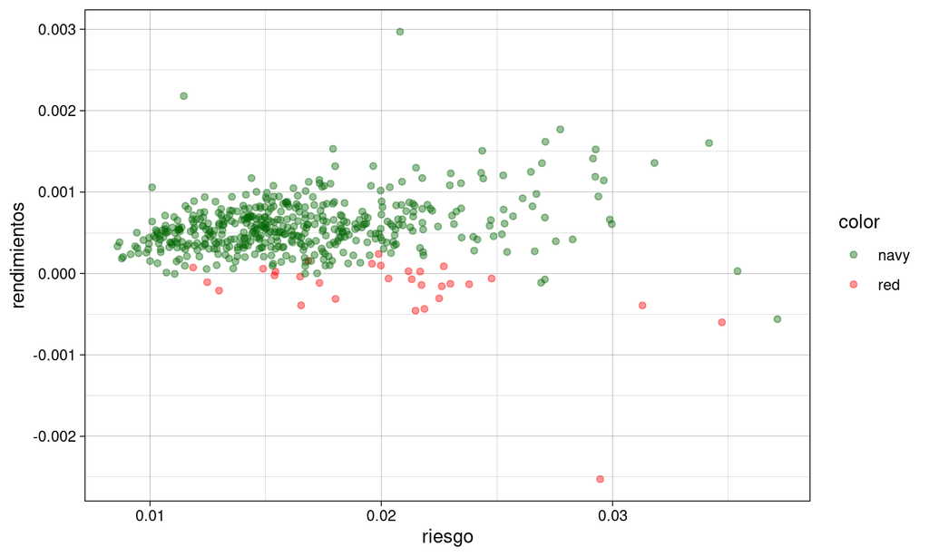

```r
ggplot(data = datos_acciones,
    aes(x = riesgo, y = rendimientos, colour = color)
       ) + geom_point(alpha = 0.4) + theme_linedraw() +
  scale_color_manual(values = c("darkgreen", "red"))
```

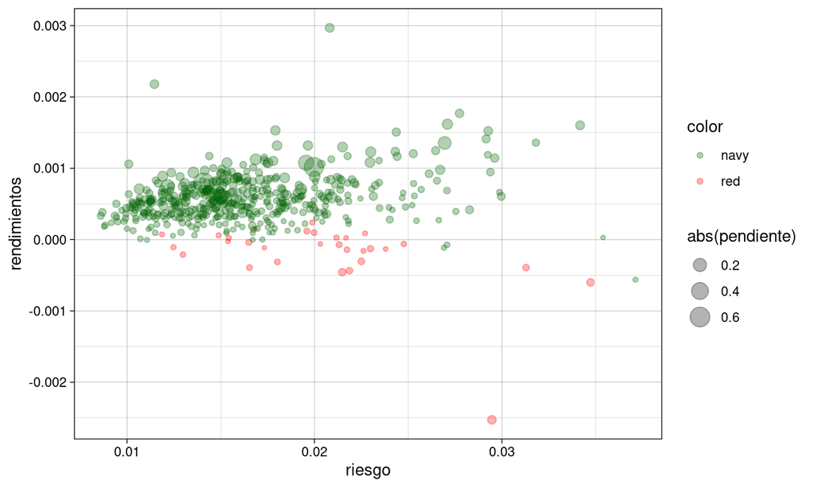

```r
ggplot(data = datos_acciones,
       aes(x = riesgo, y = rendimientos,
           colour = color, size = abs(pendiente))
       ) +  geom_point(alpha = 0.3) + theme_linedraw() +
  scale_color_manual(values = c("darkgreen", "red"))
```

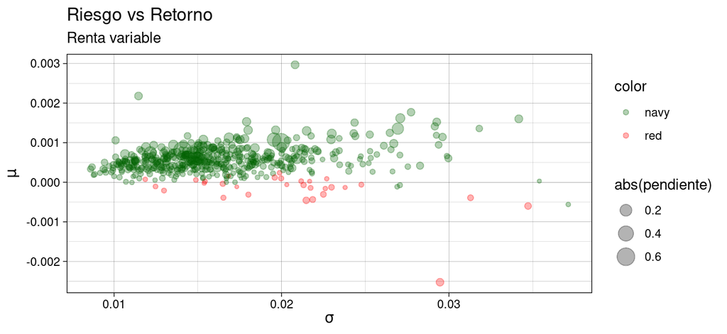

```r
ggplot(data = datos_acciones,
       aes(x = riesgo, y = rendimientos,
           colour = color, size = abs(pendiente))
       ) +  geom_point(alpha = 0.3) + theme_linedraw() +
  scale_color_manual(values = c("darkgreen", "red")) +
  ggtitle(label = "Riesgo vs Retorno", subtitle = "Renta variable") +
  ylab(label = expression(mu)) + xlab(expression(sigma))
```

Por último se puede modifiar las siguientes caracteristícas:

- Títulos: al gráfico, a los ejes y eliminar las leyendas.
- Agregar una línea línea a \(45^\circ\) y otra horizontal en cero, se debe modificar los límites en el eje *x* con la función *xlim*.

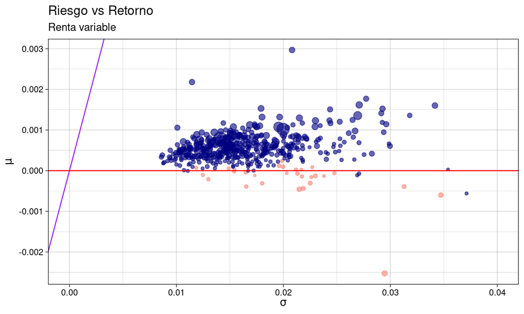

```r
 ggplot(data = datos_acciones,
       aes(x = riesgo, y = rendimientos,
           colour = color, size = abs(pendiente))
       ) +  geom_point(alpha = 0.3) + theme_linedraw() +
  scale_color_manual(values = c("navy", "salmon")) +
  ggtitle(label = "Riesgo vs Retorno", subtitle = "Renta variable") +
  ylab(label = expression(mu)) + xlab(expression(sigma)) +
  xlim(c(0, 0.04)) +  geom_hline(yintercept = 0, colour = "red") +
  geom_abline(slope = 1, intercept = 0, color = "purple") +
  theme(legend.position = "none")
```

## Optimizar el portafolio (un gran paréntesis)

Ya que tenemos el gráfico de riegos vs retorno, podemos proceder a optimizar un portafolio basados en el trabajo desarrollado por Markowitz (1952).

\[\max z= \lambda\sum_{i = 1}^{n} \mu^tx_{i} - (1-\lambda)\sum_{j = 1}^{n}\sum_{i = 1}^{n}x_{i}x_{j}\sigma_{i,j} \\ \sum_{i=1}^{n} x_{i} = 1 \\ x_{i} \ge 0 \\ \lambda \in [0, 1] \]

El modelo anterior se puede expresar de forma matricial como:

\[ \max z = \lambda \mu^tx - (1-\lambda)x^t\Sigma x \\ \sum_{i=1}^{n} x = 1 \\ x \ge 0 \\ \lambda \in [0, 1] \]

\(\mu\) es el promedio de los rendimientos. \(\Sigma\) es la matriz de varianzas y covarianzas de los rendimientos. \(x\) es la variable de decisión que indica la proporción a invertir en cada activo.

### Pasos para aplicar el modelo.

- Se necesitan los rendimientos de los activos \(ln(\frac{p_{t}}{p_{t-1}})\) en una matriz de nxm.
- Se calculan los promedios de los rendimientos.
- Calcular la matriz de varianzas y covarianzas. Para esto los activos deben tener la misma cantidad de observaciones.
- Se requiere de una herramienta para modelar y resolver el problema. Instalar el paquete *CVXR*

```r
install.packages("CVXR")
```

### CVXR

Tips para trabajar con el paquete:

- Las variables se declaran con la función *Variable()*. Es un vector columna.
- La forma cuadrática con la función *quad_form()*.
- Las restricciones se pueden crear como una *lista()*.
- El problema *Problem()*. Importante indicar si es de maximización o minimización.
- Se resuelve con *solve()*

## *dplyr*

**dplyr** implementa una gramátia para la manipulación de datos. Hay 5 verbos fundamentales:

- *select()*: Selecciona variables de acuerdo a su nombre.
- *filter()*: Selecciona elementos de la tabla dependiendo de condiciones.
- *mutate()*: Crea nuevas columnas a la tabla.
- *summarise()*: Agrega valores.
- *arrange()*: Cambia el orden de las filas.

Otras funciones utiles son:

- *group_by()*: Agrupar por variables.
- *relocate()*: Cambia el orden de las columnas.

### Ejemplo *dplyr*

### *select()*

```r
library(dplyr)
datos_acciones %>% select(1:2) %>% head(10)
## # A tibble: 10 x 2
##    rendimientos riesgo
##           <dbl>  <dbl>
##  1     0.000545 0.0180
##  2     0.00119  0.0292
##  3     0.000449 0.0184
##  4     0.000850 0.0160
##  5     0.000805 0.0163
##  6     0.000615 0.0137
##  7     0.00152  0.0293
##  8     0.000388 0.0114
##  9     0.000642 0.0135
## 10     0.000772 0.0174
```

Seleccionar las columnas 1, 4 y 7.

```r
datos_acciones %>% select(c(1, 4, 7)) %>% head(10)
## # A tibble: 10 x 3
##    rendimientos intercepto titulo
##           <dbl>      <dbl> <chr>
##  1     0.000545      -152. A
##  2     0.00119       -257. AAL
##  3     0.000449      -543. AAP
##  4     0.000850      -135. AAPL
##  5     0.000805      -265. ABBV
##  6     0.000615      -363. ABC
##  7     0.00152       -769. ABMD
##  8     0.000388      -122. ABT
##  9     0.000642      -447. ACN
## 10     0.000772      -605. ADBE
```

Se pueden seleccionar con los nombres de las variables.

```r
datos_acciones %>% select(c("riesgo", "intercepto", "pendiente")) %>%
  head(10)
## # A tibble: 10 x 3
##    riesgo intercepto pendiente
##     <dbl>      <dbl>     <dbl>
##  1 0.0180      -152.   0.0117
##  2 0.0292      -257.   0.0176
##  3 0.0184      -543.   0.0403
##  4 0.0160      -135.   0.00973
##  5 0.0163      -265.   0.0195
##  6 0.0137      -363.   0.0265
##  7 0.0293      -769.   0.0510
##  8 0.0114      -122.   0.00982
##  9 0.0135      -447.   0.0329
## 10 0.0174      -605.   0.0417
```

### *filter()*

```r
datos_acciones %>% filter(probabilidad < 0.5) %>%
  head(10)
## # A tibble: 10 x 7
##    rendimientos riesgo probabilidad intercepto  pendiente color titulo
##           <dbl>  <dbl>        <dbl>      <dbl>      <dbl> <chr> <chr>
##  1   -0.000116  0.0173       0.499      13.3   -0.0000820 red   AES
##  2    0.000301  0.0126       0.0911    -19.5    0.00180   navy  AMCR
##  3    0.0000289 0.0354       0.485      -0.605  0.000397  navy  AMD
##  4   -0.000457  0.0215       0.490     471.    -0.0245    red   APA
##  5    0.000314  0.0217       0.497     -49.5    0.00400   navy  BAC
##  6   -0.000132  0.0238       0.493      62.3   -0.000654  red   BKR
##  7    0.000503  0.0183       0.492    -116.     0.00802   navy  BSX
##  8    0.000450  0.0240       0.481     -66.1    0.00555   navy  COG
##  9    0.000172  0.0175       0.499     -10.8    0.00243   navy  DISCA
## 10   -0.000306  0.0225       0.490     278.    -0.0138    red   DVN
```

Varias codiciones se pueden realizar sobre la misma o diferente variable. Por defecto se interpreta como un \(\&\).

```r
datos_acciones %>% filter(probabilidad < 0.5, pendiente < 0) %>%
  head(10)
## # A tibble: 10 x 7
##    rendimientos riesgo probabilidad intercepto  pendiente color titulo
##           <dbl>  <dbl>        <dbl>      <dbl>      <dbl> <chr> <chr>
##  1   -0.000116  0.0173        0.499       13.3 -0.0000820 red   AES
##  2   -0.000457  0.0215        0.490      471.  -0.0245    red   APA
##  3   -0.000132  0.0238        0.493       62.3 -0.000654  red   BKR
##  4   -0.000306  0.0225        0.490      278.  -0.0138    red   DVN
##  5   -0.000107  0.0125        0.498       83.3 -0.00296   red   EXC
##  6   -0.000392  0.0313        0.490      253.  -0.0140    red   FCX
##  7   -0.000211  0.0130        0.493      104.  -0.00419   red   FE
##  8    0.0000277 0.0212        0.494       78.0 -0.00299   red   FTI
##  9   -0.000158  0.0226        0.490       49.9 -0.00153   red   HWM
## 10   -0.000313  0.0180        0.475      129.  -0.00609   red   KMI
```

¿Sí quiero un *O*?

```r
datos_acciones %>% filter(probabilidad < 0.4  | probabilidad > 0.55) %>%
  select(probabilidad, titulo)
## # A tibble: 5 x 2
##   probabilidad titulo
##          <dbl> <chr>
## 1       0.0911 AMCR
## 2       0.559  DPZ
## 3       0.554  FISV
## 4       0.594  IR
## 5       0.589  LW
```

Note que no se separa con coma *,*.

### *mutate()*

```r
datos_acciones %>%  mutate(datos_acciones, coef_var = rendimientos / riesgo) %>%
  select(6:8)
## # A tibble: 495 x 3
##    color titulo coef_var
##    <chr> <chr>     <dbl>
##  1 navy  A        0.0303
##  2 navy  AAL      0.0406
##  3 navy  AAP      0.0244
##  4 navy  AAPL     0.0533
##  5 navy  ABBV     0.0494
##  6 navy  ABC      0.0450
##  7 navy  ABMD     0.0521
##  8 navy  ABT      0.0341
##  9 navy  ACN      0.0475
## 10 navy  ADBE     0.0444
## # … with 485 more rows
```

### *relocate()*

Cambiamos el roden de las variables.

```r
datos_acciones %>% relocate(titulo, .before = rendimientos) %>%
  select(1:5)
## # A tibble: 495 x 5
##    titulo rendimientos riesgo probabilidad intercepto
##    <chr>         <dbl>  <dbl>        <dbl>      <dbl>
##  1 A          0.000545 0.0180        0.517      -152.
##  2 AAL        0.00119  0.0292        0.512      -257.
##  3 AAP        0.000449 0.0184        0.517      -543.
##  4 AAPL       0.000850 0.0160        0.524      -135.
##  5 ABBV       0.000805 0.0163        0.535      -265.
##  6 ABC        0.000615 0.0137        0.531      -363.
##  7 ABMD       0.00152  0.0293        0.525      -769.
##  8 ABT        0.000388 0.0114        0.510      -122.
##  9 ACN        0.000642 0.0135        0.532      -447.
## 10 ADBE       0.000772 0.0174        0.525      -605.
## # … with 485 more rows
```

### *arrange()*

```r
 datos_acciones %>% arrange((rendimientos)) %>%
  select(1:5)
## # A tibble: 495 x 5
##    rendimientos riesgo probabilidad intercepto pendiente
##           <dbl>  <dbl>        <dbl>      <dbl>     <dbl>
##  1    -0.00253  0.0295        0.436      835.   -0.0471
##  2    -0.000600 0.0347        0.493      475.   -0.0266
##  3    -0.000561 0.0371        0.474      -19.7   0.00191
##  4    -0.000457 0.0215        0.490      471.   -0.0245
##  5    -0.000436 0.0219        0.489      294.   -0.0154
##  6    -0.000392 0.0313        0.490      253.   -0.0140
##  7    -0.000391 0.0165        0.507      129.   -0.00594
##  8    -0.000313 0.0180        0.475      129.   -0.00609
##  9    -0.000306 0.0225        0.490      278.   -0.0138
## 10    -0.000211 0.0130        0.493      104.   -0.00419
## # … with 485 more rows
```

```r
 datos_acciones %>% arrange(desc(rendimientos)) %>%
  select(1:5)
## # A tibble: 495 x 5
##    rendimientos riesgo probabilidad intercepto pendiente
##           <dbl>  <dbl>        <dbl>      <dbl>     <dbl>
##  1      0.00297 0.0208        0.594      -891.    0.0526
##  2      0.00218 0.0115        0.589      -814.    0.0495
##  3      0.00177 0.0277        0.544      -719.    0.0451
##  4      0.00162 0.0271        0.548     -1438.    0.0909
##  5      0.00160 0.0342        0.504      -806.    0.0541
##  6      0.00153 0.0179        0.559      -973.    0.0655
##  7      0.00152 0.0293        0.525      -769.    0.0510
##  8      0.00151 0.0244        0.543      -628.    0.0421
##  9      0.00141 0.0292        0.534      -560.    0.0388
## 10      0.00136 0.0318        0.513      -371.    0.0248
## # … with 485 more rows
```

### *summarise()*

Esta función nos permite agregar la información (medias desviaciones, máximos, mínimos etc).

```r
 datos_acciones %>% summarise(
   max_ren = max(rendimientos), min_ren = min(rendimientos),
   max_riesgo = max(riesgo), min_riesgo = min(riesgo)
   )
## # A tibble: 1 x 4
##   max_ren  min_ren max_riesgo min_riesgo
##     <dbl>    <dbl>      <dbl>      <dbl>
## 1 0.00297 -0.00253     0.0371    0.00860
```

Los *‘‘verbos’’* anteriores se pueden mezclar entre ellos y con la función *group_by* podemos realizar operaciones más complejas.

### Ejemplo: Rendimientos con *dplyr*

```r
 library(readr)
 library(dplyr)
 acciones_todas <- read_csv(
   file = "../Datos/Fin_Semana_2/acciones.csv",
   col_names = TRUE, col_types = list("c", "D", "d")
   )
 head(acciones_todas)
```

```
## # A tibble: 6 x 3
##   Activo Fecha      Precio
##   <chr>  <date>      <dbl>
## 1 A      2010-01-04   22.4
## 2 A      2010-01-05   22.1
## 3 A      2010-01-06   22.1
## 4 A      2010-01-07   22.0
## 5 A      2010-01-08   22.0
## 6 A      2010-01-11   22.0
```

Antes, vamos a ordenarlos de forma descendente por fecha.

```r
acciones_todas %>% arrange(desc(Fecha))
## # A tibble: 959,154 x 3
##    Activo Fecha      Precio
##    <chr>  <date>      <dbl>
##  1 A      2017-12-29   67.0
##  2 AAL    2017-12-29   52.0
##  3 AAP    2017-12-29   99.7
##  4 AAPL   2017-12-29   42.3
##  5 ABBV   2017-12-29   96.7
##  6 ABC    2017-12-29   91.8
##  7 ABMD   2017-12-29  187.
##  8 ABT    2017-12-29   57.1
##  9 ACN    2017-12-29  153.
## 10 ADBE   2017-12-29  175.
## # … with 959,144 more rows
```

\Oo/

Con la función *group_by()* se pueden ordenar agrupando por activo.

```r
  acciones_todas <- acciones_todas %>% group_by(Activo) %>%
   arrange(desc(Fecha), .by_group = TRUE)
  head(acciones_todas, 7)
## # A tibble: 7 x 3
## # Groups:   Activo [1]
##   Activo Fecha      Precio
##   <chr>  <date>      <dbl>
## 1 A      2017-12-29   67.0
## 2 A      2017-12-28   67.4
## 3 A      2017-12-27   67.3
## 4 A      2017-12-26   67.2
## 5 A      2017-12-22   67.3
## 6 A      2017-12-21   67.5
## 7 A      2017-12-20   67.4
```

Podemos proceder a calcular los rendimientso

```r
  acciones_todas %>% mutate(
    rendimientos = log(Precio/lead(Precio))
  )
## # A tibble: 959,154 x 4
## # Groups:   Activo [495]
##    Activo Fecha      Precio rendimientos
##    <chr>  <date>      <dbl>        <dbl>
##  1 A      2017-12-29   67.0    -0.00714
##  2 A      2017-12-28   67.4     0.00223
##  3 A      2017-12-27   67.3     0.000743
##  4 A      2017-12-26   67.2    -0.00149
##  5 A      2017-12-22   67.3    -0.00252
##  6 A      2017-12-21   67.5     0.00178
##  7 A      2017-12-20   67.4    -0.00518
##  8 A      2017-12-19   67.8     0.00133
##  9 A      2017-12-18   67.7     0.000739
## 10 A      2017-12-15   67.6     0.0164
## # … with 959,144 more rows
```

Calculemos el rendimiento promedio y la desviación

```r
   acciones_todas %>% mutate(
    rendimientos = log(Precio/lead(Precio))) %>%
      summarise(Promedio = mean(rendimientos,  na.rm= TRUE),
                Desviacion = sd(rendimientos, na.rm = TRUE)
                )
## # A tibble: 495 x 3
##    Activo Promedio Desviacion
##    <chr>     <dbl>      <dbl>
##  1 A      0.000545     0.0180
##  2 AAL    0.00119      0.0292
##  3 AAP    0.000449     0.0184
##  4 AAPL   0.000850     0.0160
##  5 ABBV   0.000805     0.0163
##  6 ABC    0.000615     0.0137
##  7 ABMD   0.00152      0.0293
##  8 ABT    0.000388     0.0114
##  9 ACN    0.000642     0.0135
## 10 ADBE   0.000772     0.0174
## # … with 485 more rows
```

Se puede realizar el gráfico directamente.

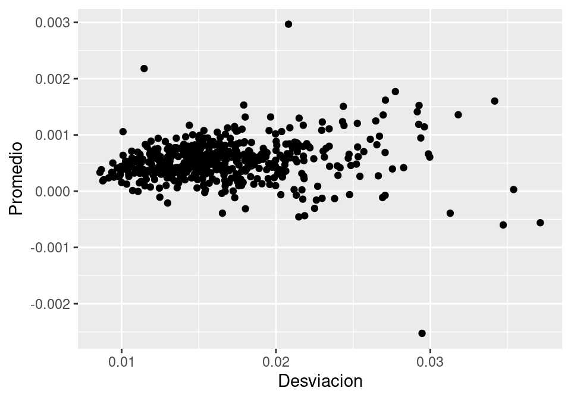

```r
    acciones_todas %>% mutate(
    rendimientos = log(Precio/lead(Precio))) %>%
      summarise(Promedio = mean(rendimientos,  na.rm= TRUE),
                Desviacion = sd(rendimientos, na.rm = TRUE)) %>%
   ggplot(aes(Desviacion, Promedio)) + geom_point()
```

## Ejercicio datos irradiación

También lo tomamos del curos de estocástica.

## *PCA en R*

## Estructuras de control

LAS estructuras de control que permiten escoger la *“dirección”* o la cantidad de veces que un conjunto de instrucciones se ejecutan dependiendo de unos parámetros establecidos y unas variables que están siendo operadas. Las más comunes son: (Wickham 2015)

- *if*
- *else if*
- *else*
- *for*
- *while*

### Estructura *if*

El *if* nos permite decidir sobre una ruta de acción partiendo de unas condiciones iniciales y una prueba lógica que marca el camino a seguir.

### Ejemplo:

Suponga que usted desea adquirir un crédito de libre inversión, de manera que se dirige a diferentes entidades bancarias para realizar la cotización. Usted lo ha reflexionado y la entidad ha escoger será aquella que ofrezca una tasa inferior al \(22\%\) efectiva anual.

Al conjunto de reglas que se deben seguir para escribir correctamente en un lenguaje de programación se le denomina *Sintaxis*. La forma adecuada de escribir un *if* en *R* es la siguiente.

Sintaxis

if (prueba lógica) {  
Sentencia 1  
Sentencia N  
}

Código

```r
i <- 0.28
if(i < 0.22){
  print("Realizar el préstamo")
}
```

Dos observaciones importantes a tener en cuenta:

- Una *prueba lógica* sólo tiene dos resultados: *Verdadero* y *Falso*.
- La sentencia solo se ejecuta en caso de que sea verdadera.

### *Else if*

Volviendo a nuestro ejemplo. Suponga que luego de investigar un poco en internet usted decide que si la tasa es menor a \(24 \%\) su decisión es: *“Lo voy a pensar”*. En tal caso se requiere de una nueva prueba. Para ello utilizamos el *else if*.

```r
i <- 0.23
if(i < 0.22){
  print("Realizar el préstamo")
}else if (i < 0.24){
  print("Lo voy a pensar")
}
## [1] "Lo voy a pensar"
```

### *Else*

Por último, si la tasa es \(\ge 24 \%\) definitivamente no se realiza el préstamo. En este caso el *else* es el complemento de las dos pruebas anteriores y no requiere ser evaluada explícitamente.

```r
i <- 0.26
if(i < 0.22){
  print("Realizar el préstamo")
}else if(i < 0.24){
  print("Lo voy a pensar")
}else{
  print("No voy a realizar el préstamo")
}
## [1] "No voy a realizar el préstamo"
```

### Observaciones

Una característica importante cuando se escribe una sentencia de decisión es que el programa ingresa a la primera prueba que es verdadera. Observemos detenidamente el siguiente código.

```r
i <- 0.18
if(i < 0.26){
  print("No voy a realizar el préstamo")
}else if(i < 0.24){
  print("Lo voy a pensar")
}
## [1] "No voy a realizar el préstamo"
```

Como el interés (\(0.18\)) es menor a \(0.26\) la primera condición es verdadera y obtenemos como respuesta *No voy a realizar el préstamo*. El énfasis se debe a que generalmente se suele pensar que el programa se va preguntando cada una de las pruebas lógicas y esto no ocurre. :’(

### Ciclos

Los ciclos nos permiten repetir un conjunto de instrucciones una *“cierta”* cantidad de veces. Nos enfocaremos principalmente en los ciclos *for* y *while*, *repeat* es uno que poco se usa en análisis de datos y se deja como consulta al investigador.

### *for*

Esta estructura requiere de una variable que indexa una secuencia de números o de elementos un conjunto. Su sintaxis es la siguiente:

for ( variable in valores ) {  
Sentencia 1  
Sentencia N  
}

### Ejemplos

```r
# Ejemplo 1

 for(i in 1:12){
   print(i)
 }
## [1] 1
## [1] 2
## [1] 3
## [1] 4
## [1] 5
## [1] 6
## [1] 7
## [1] 8
## [1] 9
## [1] 10
## [1] 11
## [1] 12
```

```r
# Ejemplo 2

cto <- c("uno", "dos", "tres",
     "cuatro","cinco", "seis",
     "siete", "ocho", "nueve")
for(k in cto){
  print(k)
}
## [1] "uno"
## [1] "dos"
## [1] "tres"
## [1] "cuatro"
## [1] "cinco"
## [1] "seis"
## [1] "siete"
## [1] "ocho"
## [1] "nueve"
```

### *while*

Este tipo de ciclo parte de una condición, en caso de que esta sea verdadera ejecuta las sentencias hasta que la prueba lógica se haga falsa.

Sintaxis

while(prueba lógica) {  
Sentencia 1  
Sentencia 2  
.  
.  
.  
Sentencia N  
}

Código

```r
cont <- 0
while(cont < 4){
  print(cont)
  cont <- cont + 1
}
## [1] 0
## [1] 1
## [1] 2
## [1] 3
```

Estos deben utilizarce con cuidado ya que si la prueba lógica no se hace *falsa* se corre con el riesgo de un bucle *“infinito”*.

### Ejercicios prácticos.

La tasa interna de retorno, *TIR*, es uno de los indicadores más utilizados en finanzas ya que indica cual debe ser la tasa mínima a la que debe rentar una inversión con el fin de no generar pérdidas ni ganancias. La *TIR* está dada por la siguiente expresión:

\[TIR = \sum_{i = 1}^{n}\frac{F_{n}}{(1 + i)^n} - I_{0}= 0\]

La ecuación anterior se puede resolver análiticamente cuando \(n\) toma valores pequeños. Si \(n\) es grande, se recurre a métodos numéricos como *bisección*.

### Bisección

Este método es utilizado para encontrar las raíces de \(f(x)\) asumiendo que la función es continua el intervalo \([a_{0}, a_{1}]\) y \(f(a_{0})*f(a_{1}) < 0\).

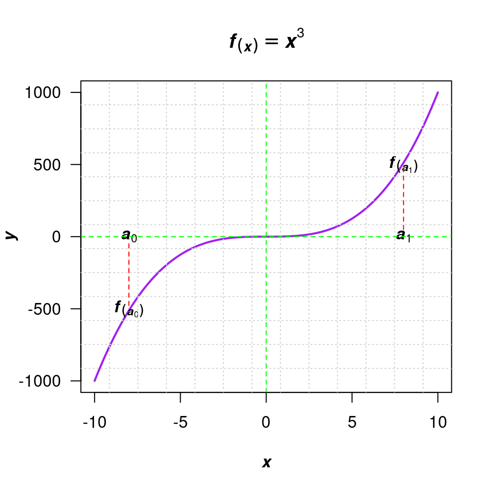

*** Diagrama de flujo del método de bisección.

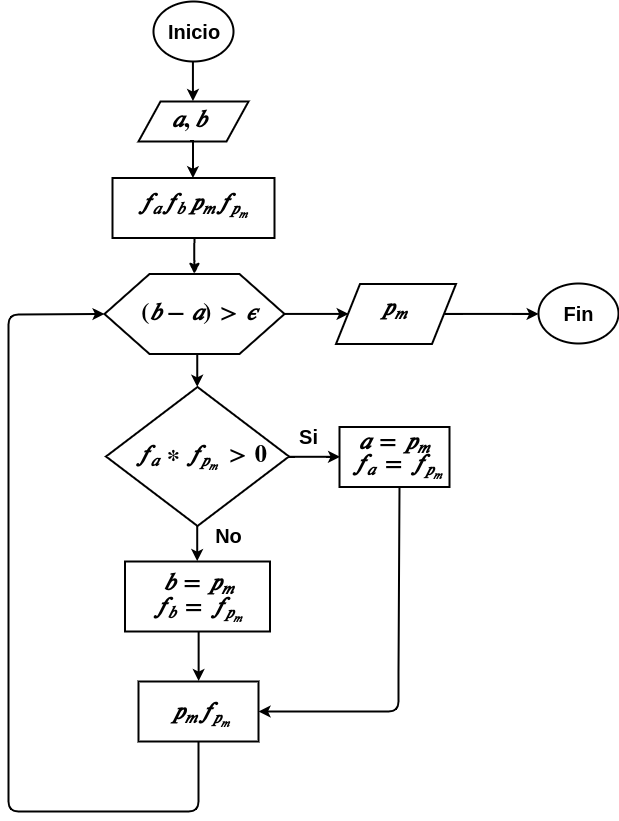

#### Ejemplo

Vamos a determinar la \(TIR\) para el siguiente flujo de caja.

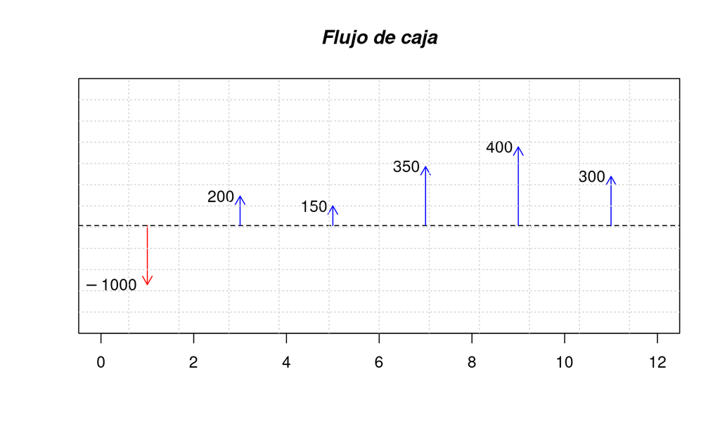

Ahora, para poder aplicar el método de bisección debemos garantizar que en un intervalo \([a, b]\) se cumpla que \(f(a)*f(b) < 0\) para que exista al menos una raíz.

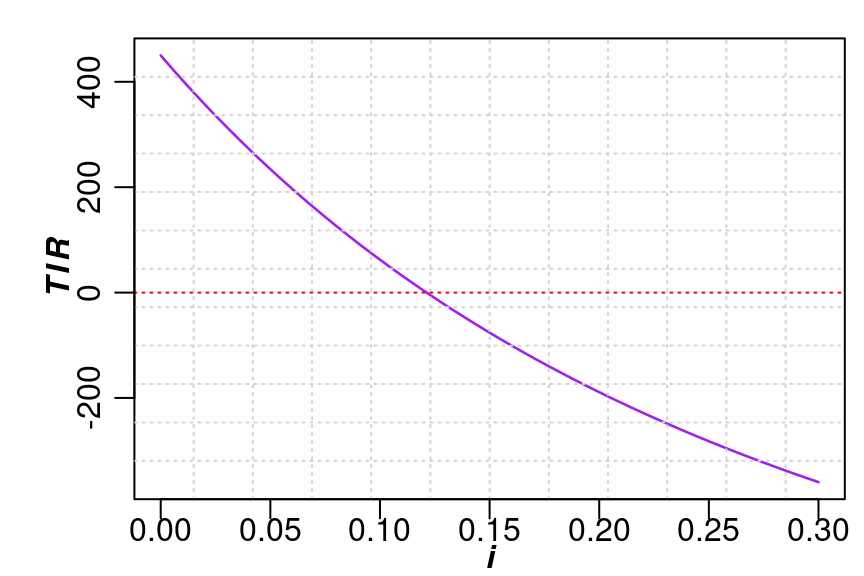

La expresión anterior se puede resolver con el método de bisección obteniendo un resultado para \(i\) de: 0.1212383.

En la \(TIR\) tradicionalmente se asume que los periodos son iguales. En caso de que los periodos de pago sean diferentes se debe recurrir a la \(TirNoPer\) (la tir no periódica) dada por la siguiente expresión: \[\sum_{k = 1}^{n}\frac{F_{n}}{(1 + i)^\frac{d_{k}-d_{1}}{365}}= 0\]

El método funciona igual debido a que lo único que cambia es el exponente del denominador.

Determine la tir no periódica del siguiente flujo de caja.

| Valores | Fechas |
| --- | --- |
| -10000 | 1 ene 08 |
| 2750 | 1 mar 08 |
| 4250 | 30 oct 08 |
| 3250 | 15 feb 09 |
| 2750 | 1 abr 09 |

El resultado para la tir no periódica es 0.3733625. *El ejemplo tomado de la ayuda de Excel*

## Simulación Montecarlo

El objetivo de esta técnica es aproximar una solución a un problema cuantitativo que abordarlo de forma análitica puede no ser muy práctico. Esto se logra a través de un muestreo estadístico.

Por ejemplo:

- Mediante simulación calcule la probabilidad de que al menos dos personas de 38 cumplan años el mismo día. Para ello lea el archivo que se encuentra en *cumple.csv* y tome muestras de manera aleatoria de tamaño 38 y calcule la probabildiad.

## Los siguientes ejercicios fueron tomados del curso de *Optimización estocástica* del programa doctorado en ingeniería dictado por el profesor John Fredy Franco Baquero el año 2022

- Una recepcionista recibió \(N=10\) sombreros y decidió devolverlod de cualquier forma. Ecuentre la probababilidad de que ningún sombrero sea entregado a su dueño mediante simulación Montecarlo.
- Usar simulación Monte Carlo para estimar la media de lanzamientos necesarios de seis dados, para que cada dado presente por lo menos una vez el valor de 6.
- Estimar la distancia media entre dos puntos en un cuadrado de lado 1 usando simulaciones Montecarlo.

Una turbina eólica genera potencia eléctrica \(P\) en función de la velocidad del viento \(v\). Según las figuras:

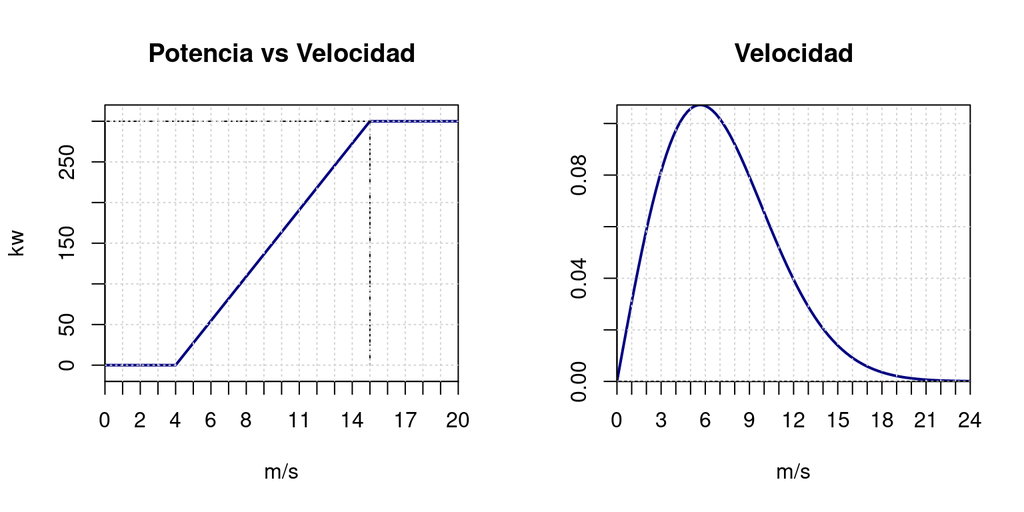

Utilizar simulación montecarlo para determinar el valore esperado de la potencia si la velocidad sigue una distribución *Weibull*

La función de distribución de *Weibull* esta dada por:

\[f(v) = \left\{\begin{array}{ll} \frac{k}{\lambda}(\frac{v}{\lambda})^{k-1} e^{-(\frac{v}{\lambda})^k} & v \ge 0\\ 0 & v\le 0 \end{array} \right. \]

Para el ejercicio tomar un valor \(k = 2\) y \(\lambda=8\).

## Algoritmo genético para solucionar el problema del agente viajero.

## Referencias

Markowitz, Harry. 1952. “Porfolio Selection.” *Journal of Finance* 7.

Wickham, Hadley. 2010. *GGplot2: Elegant Graphics for Data Analysis*. Springer Science+Business Media.

———. 2015. *Advanced r*. CRC Press.

Wilkinson, Leland. 1999. *The Grammar of Graphics*. Springer.